# 污染比 (CR) 分析 RStudio + Windows 版

msProteomiX 多引擎蛋白质组学数据处理包 — timsTOF Pro 离子淌度-质谱 (IM-MS) 污染比分析模块  
本指南面向 **Windows + RStudio** 用户。 全部操作均可在 RStudio 内完成，无需命令行知识。

## 1 概述

### 什么是 CR？

CR（Contamination Ratio，污染比）用于评估单细胞/微量蛋白质组学样品的清洁度。 它通过测量 timsTOF Pro 数据 IM-m/z 空间中 **单电荷污染物**（聚合物、表面活性剂、化学噪声）与 **多电荷肽段信号**的比例来实现。

**核心原理：**在捕获型离子淌度 (TIMS) 中，单电荷污染物的 1/K<sub>0</sub> 值显著高于同 m/z 的多电荷肽段。 利用一条分界线可将两者分开。  
**CR = ΣI<sub>污染</sub> / ΣI<sub>信号</sub> × 100%** — 数值越低越干净。

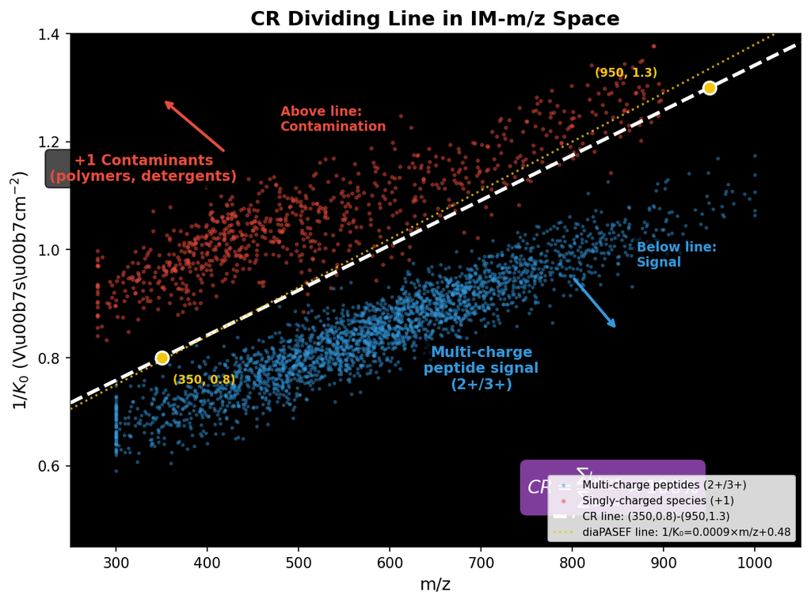

图 1：CR 分界线原理。线上方：单电荷污染物；线下方：多电荷肽段信号。

### 工作流程总览

全部流程在 **RStudio** 内完成：

| 步骤 | 内容 | 时间 |
| --- | --- | --- |
| 1 | 创建项目并复制 .d 文件 | 1 分钟 |
| 2 | `extract_cr_data()` 提取前体离子并计算 CR | 每个文件 2-5 分钟 |
| 3 | 运行 `33_contamination_ratio.R` — 交互式分组 + 自动绘图 | 1 分钟 |
| 4 | 在 `output/` 查看 HTML 报告 | — |

## 2 环境配置（仅需一次）

以下步骤只需在 Windows 电脑上执行一次。

### 2.1 安装 R + RStudio

#### 1 下载并安装

- **R** (4.3+)： [https://cran.r-project.org](https://cran.r-project.org/bin/windows/base/) — 点击 "Download R x.x.x for Windows"
- **RStudio**： https://posit.co/download/rstudio-desktop/ — 下载 Windows 安装包

全部使用默认设置安装即可。

### 2.2 安装 msProteomiX

#### 2 打开 RStudio，在控制台粘贴以下代码

```
# 安装 msProteomiX（一行即可）
if (!requireNamespace("remotes")) install.packages("remotes")
remotes::install_github("BayOmics/msProteomiX")

# 安装 reticulate（用于 R 调用 Python）
install.packages("reticulate")
```

# 预期输出： * DONE (msProteomiX) === msProteomiX v0.3.0 ===

### 2.3 安装 Python + alphatims

#### 3 方案 A：从 RStudio 内安装（最简单）

```
# 在 R 控制台执行：
reticulate::install_miniconda()     # 自动安装 Miniconda
reticulate::py_install("alphatims") # 安装 alphatims
```

**提示：**这会安装一个由 R 管理的私有 Python 环境。 你不需要单独安装 Anaconda，也不需要输入任何 Python 命令。

#### 方案 B：使用已有的 Anaconda

如果你电脑上已经有 Anaconda/Miniconda，只需在 Anaconda Prompt 中安装 alphatims：

```
# 在 Anaconda Prompt 中执行（不是 R）：
pip install alphatims
```

RStudio 的 `reticulate` 会自动检测你的 Anaconda 安装。

### 2.4 验证安装

#### 4 在 R 控制台运行

```
library(msProteomiX)    # 应打印版本信息
library(reticulate)
py_config()             # 应显示 Python 路径
py_module_available("alphatims")  # 应返回 TRUE
```

=== msProteomiX v0.3.0 === [1] TRUE

如果 `py_module_available("alphatims")` 返回 `FALSE`， 请执行 `reticulate::py_install("alphatims")`，然后重启 RStudio。

## 3 完整工作流程

### 3.1 创建项目

#### 1 创建项目文件夹

```
library(msProteomiX)
create_project("D:/Projects/CR_Analysis")
# 这会创建：
#   D:/Projects/CR_Analysis/
#     ├── scripts/      （用户脚本，包含 33_contamination_ratio.R）
#     ├── wkdir/        （数据目录）
#     └── output/       （结果输出）
```

#### 2 复制 .d 文件

将 timsTOF Pro 原始数据文件夹（`.d`）复制到 `wkdir/` 或保留在原始位置（后续指定路径即可）。

示例目录结构：

D:/data/  
├── Hela_10ng_Rep1.d/  
├── Hela_10ng_Rep2.d/  
├── MouseBrain_DDM_Rep1.d/  
├── MouseBrain_DDM_Rep2.d/  
├── MouseBrain_FFHE_Rep1.d/  
└── MouseBrain_FFHE_Rep2.d/

### 3.2 从 .d 文件提取 CR 数据

#### 3 在 R 控制台执行

```
library(msProteomiX)

# 处理某个目录下的所有 .d 文件（自动发现）
extract_cr_data(
  input_path   = "D:/data/",
  output_dir   = "wkdir/cr_output",
  n_slices     = 10,           # 每个文件取 10 个 RT 切片
  export_slices = TRUE          # 导出密度图数据
)
```

>>> Running extract_precursors.py ... Input: D:/data/ Output: D:/Projects/CR_Analysis/wkdir/cr_output Slices: 10 Python: 3.10.12 alphatims: 1.1.1 [INFO] Processing: Hela_10ng_Rep1.d [INFO] Loaded 2325916050 detector events [INFO] Slice 1/10: CR=6.4%, TIC(log2)=25.5 ... >>> Done! 6 summary file(s) in: wkdir/cr_output

**RStudio 提示：**每个 .d 文件处理需要 2-5 分钟（取决于文件大小）。 控制台会显示进度信息，请勿关闭 RStudio。

### 3.3 交互式分组与可视化

#### 4 打开并运行脚本

在 RStudio 中打开 `scripts/33_contamination_ratio.R`，点击右上角 **Source** 按钮。

脚本会自动执行以下操作：

1. **自动发现** `wkdir/cr_output/` 中的所有结果文件
2. **列出样品**：

   === Step 1: Auto-discovering CR results === >>> Found 6 sample(s): [1] Hela_10ng_Rep1 [2] Hela_10ng_Rep2 [3] MouseBrain_DDM_Rep1 [4] MouseBrain_DDM_Rep2 [5] MouseBrain_FFHE_Rep1 [6] MouseBrain_FFHE_Rep2
3. **交互式分组向导** — 按提示输入编号和组名：

   === Step 2: Sample grouping === ========================================================== Samples to group: ---------------------------------------------------------- [1] Hela_10ng_Rep1 [2] Hela_10ng_Rep2 [3] MouseBrain_DDM_Rep1 [4] MouseBrain_DDM_Rep2 [5] MouseBrain_FFHE_Rep1 [6] MouseBrain_FFHE_Rep2 ========================================================== >>> 输入样品编号 (e.g. 1-2,5): 1-2 >>> 输入组名: HeLa >>> 输入样品编号 (e.g. 1-2,5): 3-4 >>> 输入组名: DDM >>> 输入样品编号 (e.g. 1-2,5): 5-6 >>> 输入组名: FFHE >>> 分组完成? (y/n): y
4. **自动生成**所有图表和 HTML 报告

**灵活分组：**支持**任意数量**的组（不限于 3 组），组名可自由定义。 分组信息保存到 `cr_group_info.csv`，下次运行时自动加载。

### 3.4 查看结果

#### 5 检查 output/ 文件夹

output/  
├── CR_Analysis_CR_Gradient.png ← CR vs RT 曲线  
├── CR_Analysis_CR_TIC.png ← 总离子流强度  
├── CR_Analysis_CR_Heatmap_*.png ← IM-m/z 密度图  
└── CR_Analysis_CR_Report.html ← 汇总 HTML 报告

双击 `*_CR_Report.html` 即可在浏览器中查看。

## 4 结果解读

### 4.1 IM-m/z 密度图

每张密度图展示一个 RT 切片的离子分布。 **白色分界线**将污染物（上方）与肽段信号（下方）分开。 每个面板标注了 CR 值。

#### 4.1.1 HeLa 10ng（清洁参考样品）

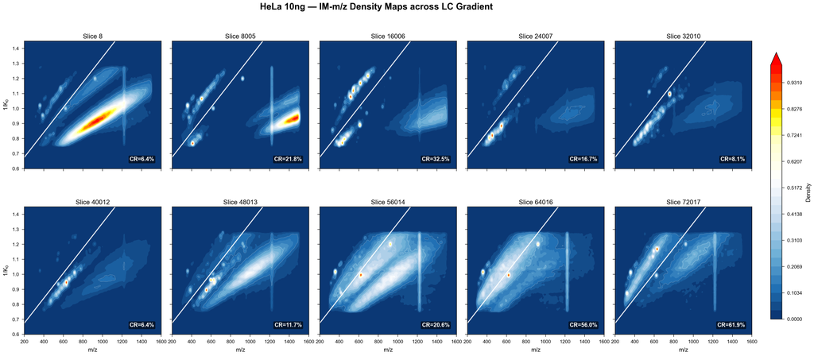

图 2a：HeLa 10ng IM-m/z 密度图。CR 范围 6.4%（梯度中段，最干净）至 61.9%（梯度末端）。

#### 4.1.2 小鼠脑组织 DDM2（高污染）

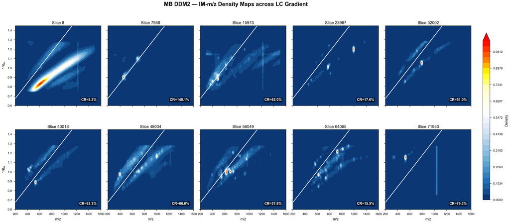

图 2b：小鼠脑 DDM2 密度图。CR 范围 8.2% 至 140.1%。分界线上方可见明显的污染物条带。

#### 4.1.3 小鼠脑组织 FFHE2（FFPE 组织）

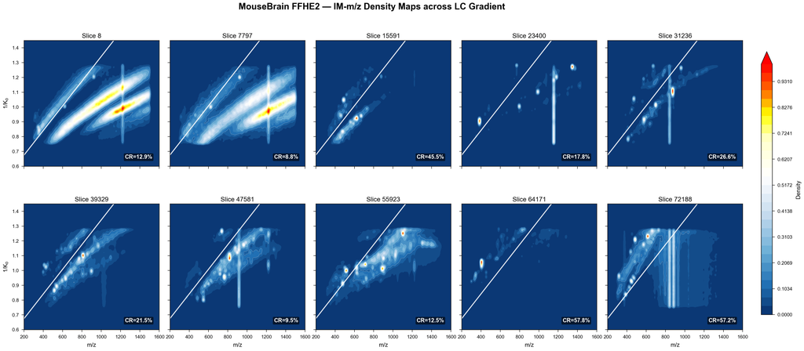

图 2c：小鼠脑 FFHE2 密度图。中等污染，梯度尾部富集。

### 4.2 CR 与 ALIF 梯度曲线

展示各样品类型污染程度随液相梯度的变化：

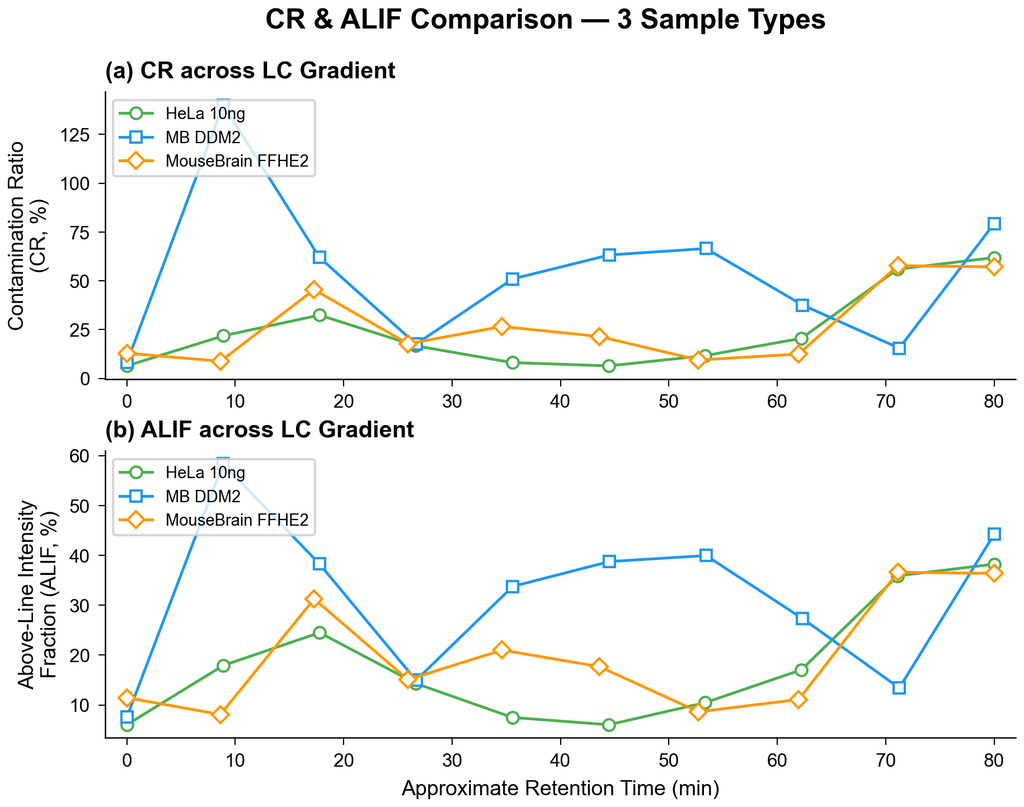

**如何解读：**

### 4.3 跨样品对比

#### 3×3 密度图矩阵

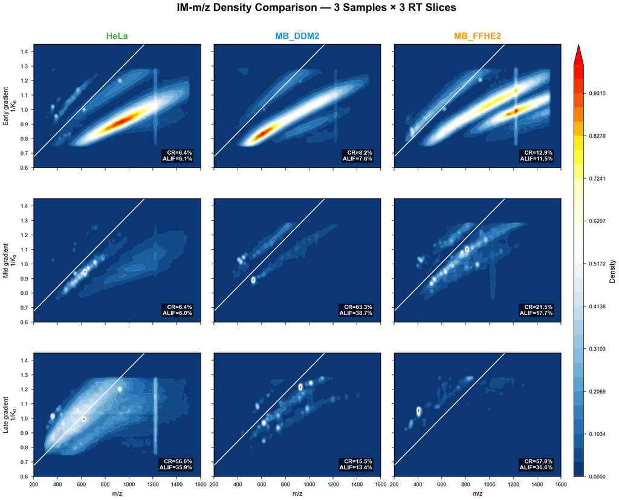

#### 样品水平汇总

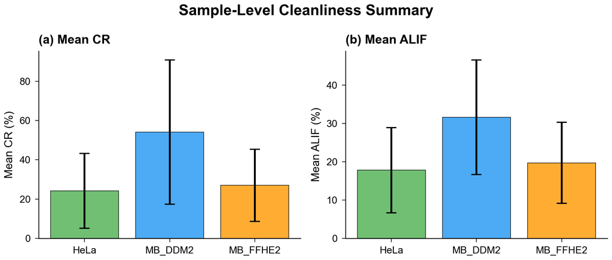

图 5：平均 CR 和 ALIF（含标准差误差线）。

### 4.4 指标鲁棒性分析

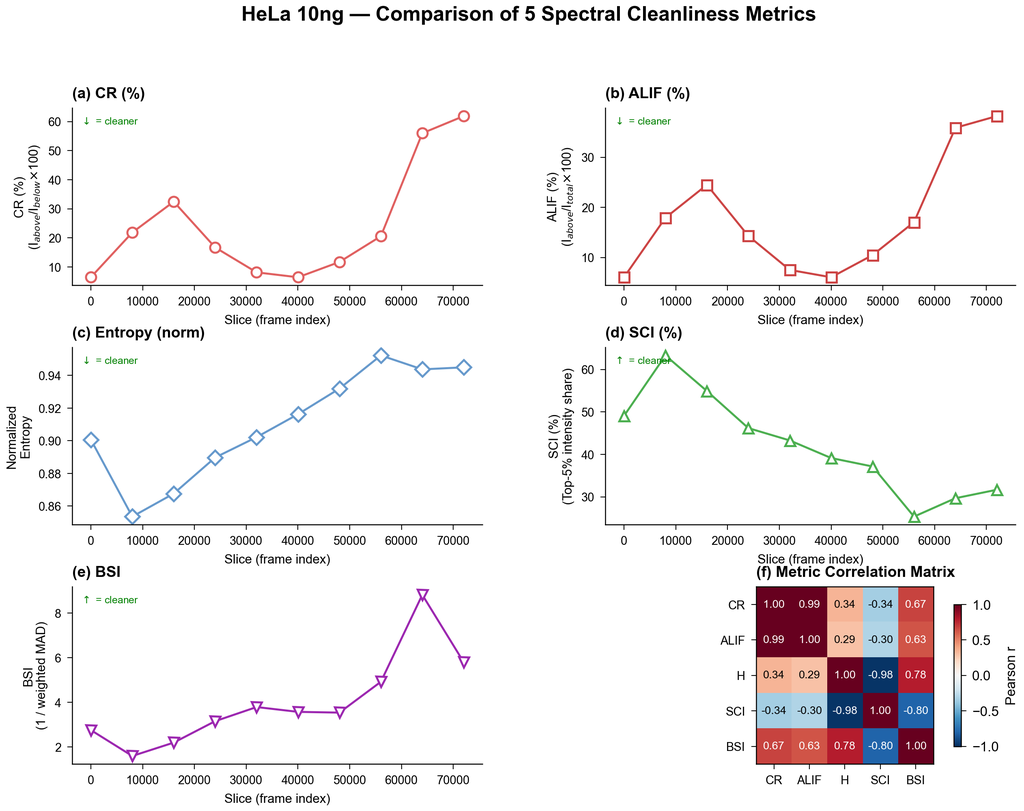

图 6：5 种光谱清洁度指标对比。CR 和 ALIF 高度相关 (r=0.99)，优于其他替代指标。

**结论：**CR 是最佳单一指标，动态范围达 10 倍。 ALIF（有界 [0, 100%]）推荐作为补充指标。

## 5 常见问题

| 问题 | 原因 | 解决方法 |
| --- | --- | --- |
| `reticulate::py_config()` 无 Python | 未安装 Python | 在 R 中执行 `reticulate::install_miniconda()` |
| `py_module_available("alphatims")` 为 FALSE | alphatims 未安装 | 执行 `reticulate::py_install("alphatims")` |
| `extract_cr_data()` 无响应 | 大文件（>10GB） | 正常现象 — 请等待 5-10 分钟，查看控制台进度 |
| CR 值全部很高 (>50%) | 样品污染或分界线不当 | 检查样品制备；调整 `LINE_POINT1/2` |
| 找不到密度图 CSV | 提取时未导出切片 | 重新运行 `extract_cr_data()`，设置 `export_slices = TRUE` |
| `Error: CR output directory not found` | 路径不匹配 | 检查脚本中 `CR_DIR` 是否与提取时的 `output_dir` 一致 |
| RStudio 提示“找不到函数” | 未加载包 | 先执行 `library(msProteomiX)` |

## 6 参数参考

### `extract_cr_data()` 函数参数

| 参数 | 默认值 | 说明 |
| --- | --- | --- |
| `input_path` | （必填） | .d 文件夹、.hdf 文件或包含它们的目录 |
| `output_dir` | `"wkdir/cr_output"` | 结果保存路径 |
| `n_slices` | `10` | 等间距 RT 切片数 |
| `export_slices` | `TRUE` | 是否导出每个切片的 CSV 文件 |
| `heatmap_rts` | `NULL` | 指定用于密度图的 RT 值（分钟），NULL = 全部 |
| `line_points` | `"350,0.8,950,1.3"` | CR 分界线: mz1,im1,mz2,im2 |
| `python` | `NULL` | Python 路径（自动检测） |

### 脚本 `33_contamination_ratio.R` 配置

| 变量 | 默认值 | 说明 |
| --- | --- | --- |
| `PROJECT_NAME` | `"CR_Analysis"` | 输出文件名前缀 |
| `CR_DIR` | `"wkdir/cr_output"` | 包含 `*_cr_summary.csv` 的目录 |
| `OUTPUT` | `"output"` | 图表和报告输出目录 |
| `LINE_POINT1` | `c(350, 0.8)` | 分界线端点 1: (m/z, 1/K<sub>0</sub>) |
| `LINE_POINT2` | `c(950, 1.3)` | 分界线端点 2: (m/z, 1/K<sub>0</sub>) |

## 附录：CR 公式推导

### 物理基础

在 TIMS 中，1/K<sub>0</sub> ∝ CCS / z。在相同 m/z 下， 单电荷离子 (z=1) 的 1/K<sub>0</sub> 比双电荷离子 (z=2) 高约 26%。

### 分界线

经过 (350, 0.8) 和 (950, 1.3) 两点  
**1/K<sub>0</sub> = 0.000833 × m/z + 0.5083**

### CR 计算

- 1/K<sub>0</sub> ≥ 分界线值 → **污染物**（单电荷）
- 1/K<sub>0</sub> < 分界线值 → **信号**（多电荷）

**CR = ΣI<sub>污染</sub> / ΣI<sub>信号</sub> × 100%**